# MS Comprehensive Exam 2022

STA 207 (100 points)

**Read the instructions on Canvas carefully!**

**Name**:

**Student ID**:

```r
library(lme4)
```

In this exam, we investigate the `ChickWeight` dataset in `R`. You can load the data using the following commands. Carefully read the help file of `ChickWeight` before working on the following questions.

```r
data(ChickWeight)
```

**(a) Briefly summarize all variables in the data set. You need to provide the definition of the variable and quantitative summary.**

**Solution:** There are 4 variables in the data set, including weight, time, chick, diet. ‘Weight’ means each chicken’s weight, and is a continuous variable. ‘Time’ means the timeline that record chicken’s weights. ‘Chick’ means the number of the chick. ‘diet’ means the feed type of the chick.

```r
# (a). (Type your code in the space below, if any)
summary(ChickWeight)
```

```
##      weight           Time           Chick     Diet
##  Min.   : 35.0   Min.   : 0.00   13     : 12   1:220
##  1st Qu.: 63.0   1st Qu.: 4.00   9      : 12   2:120
##  Median :103.0   Median :10.00   20     : 12   3:120
##  Mean   :121.8   Mean   :10.72   10     : 12   4:118
##  3rd Qu.:163.8   3rd Qu.:16.00   17     : 12
##  Max.   :373.0   Max.   :21.00   19     : 12
##                                  (Other):506
```

**(b) Visualize the weights of each chicks over time in one plot, where (i) each chick is represented by one solid curve, and (ii) the `diet` is color-coded as black (1), red (2), green (3), and blue (4). In addition to the required visualization, you may add any supporting curves, symbols, or any additional plots that you find informative.**

**Solution:** (Type your answer here)

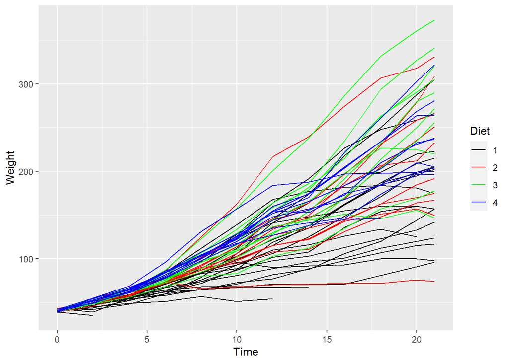

```r
# (b). (Type your code in the space below, if any)
library(ggplot2)
ggplot(data=ChickWeight,aes(x=Time,y=weight,group=Chick,color=factor(Diet)))+
  geom_line()+
  labs(x='Time',y='Weight',color='Diet')+
  scale_color_manual(values=c('black','red','green','blue'))
```

**(c) Write down an appropriate one-way ANOVA model to answer the question whether there is any changes in mean weights at Day 20 across the four diet group. To receive full credits, you need to (i) write down the model, explain your notation, constraint(s) and/or assumptions; (ii) state the null and alternative hypotheses; (iii) state the test result. You can find basic LaTeX commands at the end of this file.**

**Solution:** (Type your answer here)

```r
# (c). (Type your code in the space below, if any)
table(ChickWeight$Diet)
```

```
##
##   1   2   3   4
## 220 120 120 118
```

Constraints: $\{\alpha_i\}$ satisfied that $\sum_{i=1}^4n_i\alpha_i=0$ and $\{\epsilon_{i,j}\}$ are i.i.d. $N(0,\sigma^2)$. Assumptions: 1. variance for error terms is homogeneity. 2. the error terms follow the normal distribution. 3. the error terms are independent. null and alternative hypothesis: $H_0:\alpha_1=\alpha_2=\alpha_3=\alpha_4=0$ v.s. $H_A: not\ all\ \alpha_i\ are\ the\ zero$

```r
dt1=subset(ChickWeight,Time==20)
fit1=aov(weight~Diet,data=dt1)
summary(fit1)
```

```
##             Df Sum Sq Mean Sq F value  Pr(>F)
## Diet         3  55881   18627   5.464 0.00291 **
## Residuals   42 143190    3409
## ---
## Signif. codes:  0 '***' 0.001 '**' 0.01 '*' 0.05 '.' 0.1 ' ' 1
```

```r
qf(0.95,3,42)
```

```
## [1] 2.827049
```

Test statistics: $F^*=\frac{SSTR/df(SSTR)}{SSE/df(SSE)}\sim F_{k-1,n-k}$ where n=46,k=4, $SSTR=\sum^4_{i=1}(\bar{Y_{i.}}-\bar{Y_{..}})^2, SSE=\sum^4_{i=1}\sum_{j=1}^{n_i}(Y_{ij}-\bar{Y_{i.}})^2$ And $F^*=\frac{55881/3}{143190/42}=5.463608>2.827049$ Based on the result of the hypothesis testing performed above, we reject the null hypothesis and conclude that not all $a_i=0,i=1,2,3,4$ at significance level 0.05.

**Solution:** (Type your answer here)

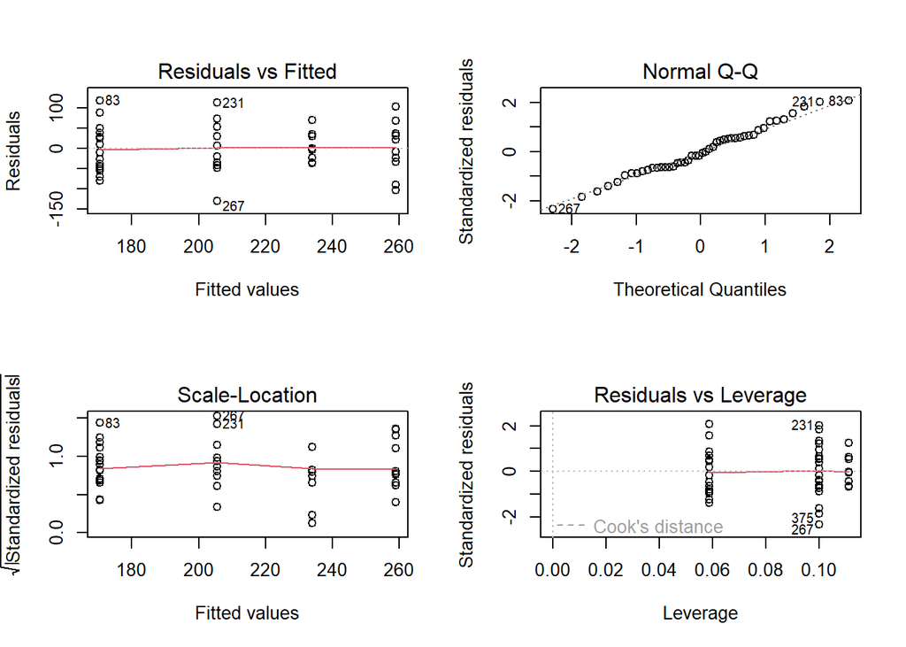

```r
# (d). (Type your code in the space below, if any)
par(mfrow=c(2,2))
plot(fit1)
```

To test outliers, we use the residuals v.s. fitted values plot, and points 83,231,267 are found, which can have a significant impact on normality and homogeneity of variance. To meet assumptions, it can be beneficial to remove outliers.

Because $n_i$s are not the same, so the homogeneity of variances can be checked using Bartlett’s test.

```r
bartlett.test(weight~Diet,data=dt1)
```

```
##
##  Bartlett test of homogeneity of variances
##
## data:  weight by Diet
## Bartlett's K-squared = 3.2498, df = 3, p-value = 0.3547
```

```r
aov_res=residuals(object=fit1)
shapiro.test(x=aov_res)
```

```
##
##  Shapiro-Wilk normality test
##
## data:  aov_res
## W = 0.98573, p-value = 0.8378
```

Normality assumption can also be checked by Shapiro-Wilk normality test. The p-value is 0.8378 that is larger than 0.05. Therefore, we can accept the null hypothesis that the error terms follow the normal distribution.

**(e) Write down an appropriate two-way ANOVA model with fixed effect to answer the question whether there is any differences in growth rates across the four diet groups. Here the growth rate can be roughly seen as the effects of `Time` on `weight`. To receive full credits, you need to (i) write down the model, explain your notation, constraint(s) and/or assumptions; (ii) state the null and alternative hypotheses; (iii) state the test result. Hint: You may want to recycle the answer in (c) to save time.**

**Solution:** Model:$Y_{ijk}=\mu_{..}+\alpha_i+\beta_j+(\alpha\beta)_{i,j}+\epsilon_{ijk},j=1,...,12,i=1,2,3,4,k=1,2,...,n_{i,j}$ notation:$Y_{ijk}$ means the weight of kth chicken under ith feed type and jth time, $\mu$ means the average weight of chicken, $\alpha_i$ means the effect from the four feed types, $\beta_j$ are the main effects of time , $(\alpha\beta)_{i,j}$ is the interaction effect between the ith diet and the jth time, $\epsilon_{ijk}$ means the unexplained effects on weights. And value $n_{i,j}$ can be found in the following table.

```r
table(ChickWeight$Time,ChickWeight$Diet)
```

```
##
##       1  2  3  4
##   0  20 10 10 10
##   2  20 10 10 10
##   4  19 10 10 10
##   6  19 10 10 10
##   8  19 10 10 10
##   10 19 10 10 10
##   12 19 10 10 10
##   14 18 10 10 10
##   16 17 10 10 10
##   18 17 10 10 10
##   20 17 10 10  9
##   21 16 10 10  9
```

Constraints: $\{\alpha_i\}$ satisfied that $\sum_{i=1}^4n_i\alpha_i=0$, $\{\beta_j\}$ satisfied that $\sum_{i=1}^{12}\beta_j=0$, $\sum_{i=1}^4(\alpha\beta)_{i,j}=0$ for all i, $\sum_{j=1}^{12}=(\alpha\beta)_{i,j}=0$ for all j, $\{\epsilon_{i,j}\}$ are i.i.d. $N(0,\sigma^2)$. Assumptions: 1. variance for error terms is homogeneity. 2. the error terms follow the normal distribution. 3. the error terms are independent. null and alternative hypothesis: $H_0:\alpha_1=\alpha_2=\alpha_3=\alpha_4=0$ v.s. $H_A: not\ all\ \alpha_i\ are\ the\ zero$ $H_0:\beta_1=...=\beta_{12}=0$ v.s. $H_A: not\ all\ \beta_j\ are\ the\ zero$

```r
# (e). (Type your code in the space below, if any)
fit2=aov(weight~factor(Time)*Diet,data=ChickWeight)
summary(fit2)
```

```
##                    Df  Sum Sq Mean Sq F value   Pr(>F)
## factor(Time)       11 2067050  187914 157.808  < 2e-16 ***
## Diet                3  129721   43240  36.313  < 2e-16 ***
## factor(Time):Diet  33   86676    2627   2.206 0.000172 ***
## Residuals         530  631110    1191
## ---
## Signif. codes:  0 '***' 0.001 '**' 0.01 '*' 0.05 '.' 0.1 ' ' 1
```

test results: The p-value of time and diet are both <2e-16 and the p-value for the interactive term is 0.000172. Therefore, we can reject the null hypothesis that both time and diet have significant impact on the response variable.

Hypothesis: $H_0:(\alpha\beta)_{ij}=0,j=1,...,12,i=1,..,4$ v.s. $H_a: not all (\alpha\beta)_{ij}=0,j=1,...,12,i=1,..,4$ To test $H_0$, we build a Full model and a reduced model: Full model:$Y_{ijk}=\mu_{..}+\alpha_i+\beta_j+(\alpha\beta)_{i,j}+\epsilon_{ijk},j=1,...,12,i=1,2,3,4,k=1,2,...,n_{i,j}$ Reduced model:$Y_{ijk}=\mu_{..}+\alpha_i+\beta_j+\epsilon_{ijk},j=1,...,12,i=1,2,3,4,k=1,2,...,n_{i,j}$ All the notation of full model and reduced model are the same except that there are no interaction terms in reduced model.

```r
fit4=aov(weight~factor(Time)+Diet,data=ChickWeight)
anova(fit4,fit2)
```

```
## Analysis of Variance Table
##
## Model 1: weight ~ factor(Time) + Diet
## Model 2: weight ~ factor(Time) * Diet
##   Res.Df    RSS Df Sum of Sq      F   Pr(>F)
## 1    563 717785
## 2    530 631110 33     86676 2.2057 0.000172 ***
## ---
## Signif. codes:  0 '***' 0.001 '**' 0.01 '*' 0.05 '.' 0.1 ' ' 1
```

```r
(717785-631110)/43/(631110/530)
```

```
## [1] 1.692763
```

```r
qf(0.95,33,530)
```

```
## [1] 1.458518
```

**(f) We want to take the chick-specific effect into account. The new mixed effect model is based on the model in (e), where `Time` is treated as a continuous covariate instead of a categorical factor, and a random intercept and a random slope (of `Time`) are added into the model. Report the fitted coefficients of the fixed effects, and summarize your findings from this model. Hint: You do not need to write down the new model, but you may find it helpful.**

**Solution:** (Type your answer here)

```r
# (f). (Type your code in the space below, if any)
ChickWeight$Time=as.numeric(ChickWeight$Time)
fit3=lmer(weight~Diet+Time+Diet:Time+(1+Time|Chick),data=ChickWeight)
summary(fit3)
```

```
## Linear mixed model fit by REML ['lmerMod']
## Formula: weight ~ Diet + Time + Diet:Time + (1 + Time | Chick)
##    Data: ChickWeight
##
## REML criterion at convergence: 4781.5
##
## Scaled residuals:
##     Min      1Q  Median      3Q     Max
## -2.7223 -0.5672 -0.0343  0.4579  3.5184
##
## Random effects:
##  Groups   Name        Variance Std.Dev. Corr
##  Chick    (Intercept) 116.91   10.812
##           Time         10.92    3.305   -0.97
##  Residual             163.37   12.782
## Number of obs: 578, groups:  Chick, 50
##
## Fixed effects:
##             Estimate Std. Error t value
## (Intercept)  33.6613     2.9192  11.531
## Diet2        -5.0277     5.0108  -1.003
## Diet3       -15.4110     5.0108  -3.076
## Diet4        -1.7505     5.0179  -0.349
## Time          6.2770     0.7614   8.245
## Diet2:Time    2.3321     1.3044   1.788
## Diet3:Time    5.1459     1.3044   3.945
## Diet4:Time    3.2550     1.3051   2.494
##
## Correlation of Fixed Effects:
##            (Intr) Diet2  Diet3  Diet4  Time   Dt2:Tm Dt3:Tm
## Diet2      -0.583
## Diet3      -0.583  0.339
## Diet4      -0.582  0.339  0.339
## Time       -0.880  0.513  0.513  0.512
## Diet2:Time  0.514 -0.882 -0.299 -0.299 -0.584
## Diet3:Time  0.514 -0.299 -0.882 -0.299 -0.584  0.341
## Diet4:Time  0.514 -0.299 -0.299 -0.882 -0.583  0.340  0.340
```

```r
#names(summary(fit3)$coefficients)
```

The random intercept and slope terms for each chick capture the variation in the intercept and slope of the regression lines across the population of chicks. The standard deviations of the random effects (sd(Intercept) and sd(Time)) can be used to quantify the amount of variation in the intercept and slope of the regression lines across the population of chicks.

## Overall, the mixed effect model with chick-specific effects provides a more nuanced and accurate description of the relationship between chick weight and diet over time, as it takes into account the natural variation between individual chicks.

**(g) Assume that the chicks in each diet are randomly selected from the same population, i.e., the enrollment of chicks is independent from any other factors. State the Stable Unit Treatment Value Assumption, write down the potential outcomes (weight at Day 20), and verify whether the randomization assumption holds. (This question will be replaced by another, since causal inference will not be covered this quarter.)**

**Solution:** (Type your answer here)

**LaTeX commands**

$$Y_{i,j,k}, \mu, \alpha, \beta, \epsilon,
i, j, H_0, H_a, \neq, =, \ldots$$